# MATH-256 - Mock Exam #2 (Fall 2021)

These questions are intended to help you practice for Exam #2. The real exam will feature 2-3 questions that follow a similar format. All course content up until this point may appear on the exam, though the primary focus will be on Chapters 3, 4, and 5.1 of the textbook, the probability, random variables, and central limit theorem lecture slides, and Labs 3 and 4.

On the actual exam you should be prepared to record your answers in a properly formatted R Markdown document, submitting the compiled HTML output.

$~$

### Question #1

A party host purchases ice cream in 1.5 quart boxes (48 ounces), and serves ice cream to guests using an ice cream scoop that holds about 2 ounces. However, there is some variability in both the amount of ice cream in a box, as well as the amount of ice cream in a given scoop.

Let the random variable $X$ denote the amount of ice cream (in ounces) in a randomly chosen box, and let the random variable $Y$ denote the amount of ice cream (in ounces) of a random scoop. The expected value of $X$ is 48 ounces, with a standard deviation of 0.5 ounces, while the expected value of $Y$ is 2, with a standard deviation of 0.25 ounces.

$~$

**1-A**: What is the expected amount of ice cream that remains in a box after 2 scoops have been served? What is the standard deviation of this amount? Show your work.

$~$

**1-B**: Suppose the amount of ice cream in a random box is represented by a N(48,0.5) probability model. According to this model, how much ice cream is in a box that is the 95th percentile in terms of its ice cream content?

$~$

**1-C**: Suppose the amount of ice cream in a random scoop can be represented by a N(2,0.25) probability model. What is the probability that a random scoop contains between 1.5 and 1.9 ounces of ice cream?

$~$

**1-D**: Consider *five* independently drawn random scoops of ice cream. Using the probability you obtained in 1-C, what the probability that *exactly 2* of these five scoops contain between 1.5 and 1.9 ounces of ice cream?

$~$

### Question #2

Assortative mating is a hypothesized non-random mating pattern where individuals select a partner with similar expressed characteristics. The table below summarizes the eye colors of a random sample of 204 Scandinavian men and their female partners (for simplicity only monogamous, heterosexual relationships were sampled).

|  | Female_Blue | Female_Brown | Female_Green | Total |
| --- | --- | --- | --- | --- |
| Male_Blue | 78 | 23 | 13 | 114 |
| Male_Brown | 19 | 23 | 12 | 54 |
| Male_Green | 11 | 9 | 16 | 36 |
| Total | 108 | 55 | 41 | 204 |

$~$

**2-A**: Using these data, estimate probability that either a randomly chosen male or his female partner have blue eyes?

$~$

**2-B**: Suppose a Scandinavian male has blue eyes. Using these data, estimate the probability that his female partner also has blue eyes.

$~$

**2-C**: Consider a random sample of $n = 10$ couples drawn from the population represented by the couples in this sample (you may assume the population is large, making each selection independent). Letting the random variable $X$ represent the number of couple where both members have blue eyes, provide a probability model for $X$ (be sure to specify numeric values for the model’s parameters).

$~$

**2-D**: Using the probability model you described in 2-C, what is the probability that *five or fewer* couples both have blue eyes in a random sample of $n = 10$ Scandinavian couples.

$~$

### Question #3

The Iowa City Homes dataset contains information on homes sold in Iowa City, IA between 2005 and 2008. It was scraped from the Johnson County county assessor website by University of Iowa professor to help them understand the local housing market. It contains information such as the home’s sale price, assessed value, square footage, and a variety of other features.

```r
homes <- read.csv("https://remiller1450.github.io/data/IowaCityHomeSales.csv")
```

**3-A**: Construct a Q-Q plot of the variable “sale.amount” in the full dataset. Based upon this plot, does this variable appear to be Normally distributed?

$~$

**3-B**: Let the random variable $X$ denote the sample average of a randomly chosen sample of $n = 35$ homes from the Iowa City Homes dataset. Provide a probability model for $X$ (be sure to specify numeric values for the model’s parameters).

$~$

**3-C**: In the graphs that appear below, each histogram displays the normalized values of a variable in the Iowa City Homes dataset and corresponds with one of the QQ-plots on the right. For Question 3-C, match each variable (ie: “sale.amount”, “bedrooms”, or “lat”) with the corresponding QQ plot of that variable (ie: “A”, “B”, or “C”). No use of R is required for this question.

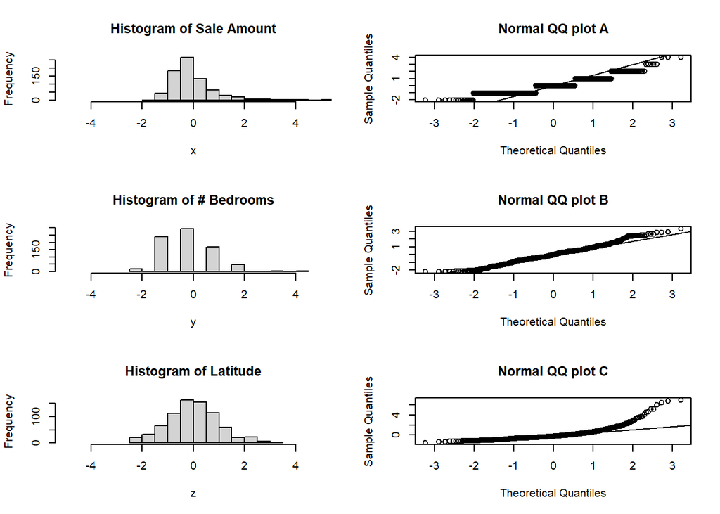